# CovidRidership

```python
import numpy as np
import pandas as pd
import matplotlib.pyplot as plt
import seaborn as sns
pd.set_option("display.max_columns", None)
```

Read in ridership data from SANDAG open data portal as pandas dataframe

```python
ridership = pd.read_csv("Downloads/SOC_-_Transit_Ridership_by_Route___Stop__SANDAG__20240520.csv")
# Look at first few records to see variables
ridership.head()
```

|  | Calendar Year | ROUTE_NUMBER | ROUTE_NAME | DIRECTION_NAME | SERVICE_CODE | SERVICE_TYPE | SERVICE_CLASS | SERVICE_MODE | SORT_ORDER | STOP_ID | STOP | AVG_SEGMENT_MILES | TRIPS | TRIPS_GROSS | SUM_PASSENGERS_ON | SUM_PASSENGERS_OFF | SUM_LOAD | AVG_LOAD | CITY | STOP_KEY | SUM_PASSENGER_MILES | AVG_PASSENGER_MILES |
| --- | --- | --- | --- | --- | --- | --- | --- | --- | --- | --- | --- | --- | --- | --- | --- | --- | --- | --- | --- | --- | --- | --- |
| 0 | 2019 | 1 | Route #1 Fashion Valley to La Mesa | East | MTS | Local | Bus - Direct | Bus | 10.0 | 94048.0 | Fashion Valley Transit Center | 0.67 | 62.0 | 2763.0 | 342 | 0.00 | 342.18 | 5.52 | San Diego | 94048.0 | 229.81 | 3.71 |
| 1 | 2019 | 1 | Route #1 Fashion Valley to La Mesa | East | MTS | Local | Bus - Direct | Bus | 20.0 | 13510.0 | Hotel Circle South / Bachman Pl | 1.67 | 62.0 | 2763.0 | 12 | 16.41 | 338.18 | 5.45 | NaN | 13510.0 | 564.09 | 9.10 |
| 2 | 2019 | 1 | Route #1 Fashion Valley to La Mesa | East | MTS | Local | Bus - Direct | Bus | 30.0 | 10478.0 | University Av / 7th Av | 0.08 | 62.0 | 2763.0 | 56 | 27.67 | 366.50 | 5.91 | San Diego | 10478.0 | 29.58 | 0.48 |
| 3 | 2019 | 1 | Route #1 Fashion Valley to La Mesa | East | MTS | Local | Bus - Direct | Bus | 40.0 | 13391.0 | University Av / 8th Av | 0.12 | 62.0 | 2763.0 | 28 | 8.05 | 386.64 | 6.24 | San Diego | 13391.0 | 46.71 | 0.75 |
| 4 | 2019 | 1 | Route #1 Fashion Valley to La Mesa | East | MTS | Local | Bus - Direct | Bus | 50.0 | 10106.0 | University Av / 10th Av | 0.11 | 62.0 | 2763.0 | 36 | 12.71 | 410.38 | 6.62 | San Diego | 10106.0 | 43.13 | 0.70 |

I will focus on rail line ridership for now. It would be interesting to compare to local and rapid bus lines later.

First I need to get the total ridership along each line. I will do this by summing up the boarding numbers at each station so that I end up with a total per line, direction, and year.

```python
rail_boardings = ridership[ridership["SERVICE_MODE"]=="Rail"].groupby(["ROUTE_NAME", "DIRECTION_NAME", "Calendar Year"])["SUM_PASSENGERS_ON"].sum()
print(rail_boardings)
```

```
ROUTE_NAME                      DIRECTION_NAME  Calendar Year
Green Line Trolley              East            2019             15732
                                                2020              5892
                                                2021              7673
                                                2022             10327
                                West            2019             15312
                                                2020              5811
                                                2021              7340
                                                2022             10645
Orange Line Trolley             East            2019             12932
                                                2020              5682
                                                2021              6223
                                                2022              9481
                                West            2019             12871
                                                2020              5642
                                                2021              6054
                                                2022              9386
Route #398                      North           2019              2221
                                                2020               197
                                South           2019              2430
                                                2020               226
SPRINTER                        East            2019              4257
                                                2020              2002
                                                2021              2139
                                                2022              2405
                                West            2019              4297
                                                2020              2007
                                                2021              2199
                                                2022              2426
UC San Diego Blue Line Trolley  North           2019             30334
                                                2020             12792
                                                2021             18291
                                                2022             33088
                                South           2019             27581
                                                2020             11617
                                                2021             16182
                                                2022             30835
Name: SUM_PASSENGERS_ON, dtype: int64
```

```python
# Convert back to dataframe
rail_boardings_df = rail_boardings.reset_index()
rail_boardings_df.head()
```

|  | ROUTE_NAME | DIRECTION_NAME | Calendar Year | SUM_PASSENGERS_ON |
| --- | --- | --- | --- | --- |
| 0 | Green Line Trolley | East | 2019 | 15732 |
| 1 | Green Line Trolley | East | 2020 | 5892 |
| 2 | Green Line Trolley | East | 2021 | 7673 |
| 3 | Green Line Trolley | East | 2022 | 10327 |
| 4 | Green Line Trolley | West | 2019 | 15312 |

Now I will check to see if ridership is the same in both directions for each line. To do this, I'll calculate the percent difference between the two directions after summing up ridership for all years.

```python
rail_boardings_df_sum_year = rail_boardings_df.groupby(["ROUTE_NAME", "DIRECTION_NAME"])["SUM_PASSENGERS_ON"].sum().reset_index()
rail_boardings_df_sum_year["pct_change"] = rail_boardings_df_sum_year.groupby(["ROUTE_NAME"])["SUM_PASSENGERS_ON"].pct_change()
rail_boardings_df_sum_year
```

|  | ROUTE_NAME | DIRECTION_NAME | SUM_PASSENGERS_ON | pct_change |
| --- | --- | --- | --- | --- |
| 0 | Green Line Trolley | East | 39624 | NaN |
| 1 | Green Line Trolley | West | 39108 | -0.013022 |
| 2 | Orange Line Trolley | East | 34318 | NaN |
| 3 | Orange Line Trolley | West | 33953 | -0.010636 |
| 4 | Route #398 | North | 2418 | NaN |
| 5 | Route #398 | South | 2656 | 0.098428 |
| 6 | SPRINTER | East | 10803 | NaN |
| 7 | SPRINTER | West | 10929 | 0.011663 |
| 8 | UC San Diego Blue Line Trolley | North | 94505 | NaN |
| 9 | UC San Diego Blue Line Trolley | South | 86215 | -0.087720 |

Most lines are similar in both directions besides Route 398 (Coaster) and the Blue line. I am not sure what might cause the difference in Coaster, but it's a pretty small sample size so I'll ignore it for the moment. The Blue line is interesting. I wonder if some of the effect might come from migrants crossing the border and then taking the blue line up North. To test this hypothesis, I'll compare boarding numbers going North and alighting numbers going South at San Ysidro Station.

```python
blue_san_ysidro = ridership.query('ROUTE_NUMBER == 510 and STOP == "San Ysidro Station"').groupby(["DIRECTION_NAME"]).sum()
san_ysidro_diff = blue_san_ysidro.query('DIRECTION_NAME == "North"')["SUM_PASSENGERS_ON"].item() - blue_san_ysidro.query('DIRECTION_NAME == "South"')["SUM_PASSENGERS_OFF"].item()
san_ysidro_diff
```

```
6709.029999999999
```

So the Blue line has a surplus of 6709 boardings (traveling North) over alightings (traveling South) at San Ysidro. Next I'll calculate the total difference between the number of passengers traveling North versus South throughout the entire Blue line so that I can compare.

```python
blue_diff = rail_boardings_df_sum_year.query('ROUTE_NAME == "UC San Diego Blue Line Trolley" and DIRECTION_NAME == "North"')["SUM_PASSENGERS_ON"].item() - rail_boardings_df_sum_year.query('ROUTE_NAME == "UC San Diego Blue Line Trolley" and DIRECTION_NAME == "South"')["SUM_PASSENGERS_ON"].item()
diff = san_ysidro_diff / blue_diff
print(format(diff, ".0%"))
```

```
81%
```

So San Ysidro Station accounts for 81% of the difference between North and South-bound passengers riding the Blue line. This agrees with my hypothesis, but doesn't prove anything. There could be other explanations, such as people taking the blue line North but a different line/mode back South. Or it could have something to do with how SANDAG is collecting this ridership data.

Now I will look at Covid ridership. Since direction does make a difference for ridership for some lines, I think it makes sense to average over both directions when looking at ridership numbers. This way, I will still count one-way riders, but with half the weight as round-trip riders.

```python
rail_boardings_avg = rail_boardings.groupby(["ROUTE_NAME", "Calendar Year"]).mean().reset_index()
# Rename Route #398 as COASTER and Calendar Year variable as CALENDAR_YEAR
rail_boardings_avg = rail_boardings_avg.replace("Route #398", "COASTER")
rail_boardings_avg = rail_boardings_avg.rename(columns={"Calendar Year":"CALENDAR_YEAR"})
rail_boardings_avg
```

|  | ROUTE_NAME | CALENDAR_YEAR | SUM_PASSENGERS_ON |
| --- | --- | --- | --- |
| 0 | Green Line Trolley | 2019 | 15522.0 |
| 1 | Green Line Trolley | 2020 | 5851.5 |
| 2 | Green Line Trolley | 2021 | 7506.5 |
| 3 | Green Line Trolley | 2022 | 10486.0 |
| 4 | Orange Line Trolley | 2019 | 12901.5 |
| 5 | Orange Line Trolley | 2020 | 5662.0 |
| 6 | Orange Line Trolley | 2021 | 6138.5 |
| 7 | Orange Line Trolley | 2022 | 9433.5 |
| 8 | COASTER | 2019 | 2325.5 |
| 9 | COASTER | 2020 | 211.5 |
| 10 | SPRINTER | 2019 | 4277.0 |
| 11 | SPRINTER | 2020 | 2004.5 |
| 12 | SPRINTER | 2021 | 2169.0 |
| 13 | SPRINTER | 2022 | 2415.5 |
| 14 | UC San Diego Blue Line Trolley | 2019 | 28957.5 |
| 15 | UC San Diego Blue Line Trolley | 2020 | 12204.5 |
| 16 | UC San Diego Blue Line Trolley | 2021 | 17236.5 |
| 17 | UC San Diego Blue Line Trolley | 2022 | 31961.5 |

I'll plot the ridership numbers for each line from 2019-2022.

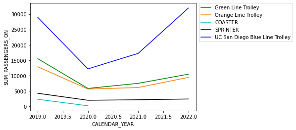

```python
sns.lineplot(x="CALENDAR_YEAR", y="SUM_PASSENGERS_ON", hue="ROUTE_NAME", data=rail_boardings_avg,
            palette={'UC San Diego Blue Line Trolley':'b', 'Green Line Trolley':'g',
                     'Orange Line Trolley':'tab:orange', 'COASTER':'c', 'SPRINTER':'k'})
plt.legend(bbox_to_anchor=(1.02, 1), loc='upper left', borderaxespad=0)
```

We can see that ridership clearly dips in 2020 for all lines. However, it is difficult to compare impacts on different lines when looking at raw ridership numbers, so I will normalize to 2019 ridership levels for each line so that we can see the percentage of 2019 ridership each year.

```python
# First get 2019 ridership for each line
rail_boardings_avg_2019 = rail_boardings_avg.query('CALENDAR_YEAR == 2019')
rail_boardings_avg_2019 = rail_boardings_avg_2019.rename(columns={"SUM_PASSENGERS_ON":"PASSENGERS_2019"})
# Join to boardings
rail_boardings_avg_join = rail_boardings_avg.merge(rail_boardings_avg_2019, left_on="ROUTE_NAME", right_on="ROUTE_NAME")
# Divide by 2019 ridership to normalize
rail_boardings_avg_norm = rail_boardings_avg_join
rail_boardings_avg_norm["Norm"] = rail_boardings_avg_norm["SUM_PASSENGERS_ON"] / rail_boardings_avg_norm["PASSENGERS_2019"]
rail_boardings_avg_norm
```

|  | ROUTE_NAME | CALENDAR_YEAR_x | SUM_PASSENGERS_ON | CALENDAR_YEAR_y | PASSENGERS_2019 | Norm |
| --- | --- | --- | --- | --- | --- | --- |
| 0 | Green Line Trolley | 2019 | 15522.0 | 2019 | 15522.0 | 1.000000 |
| 1 | Green Line Trolley | 2020 | 5851.5 | 2019 | 15522.0 | 0.376981 |
| 2 | Green Line Trolley | 2021 | 7506.5 | 2019 | 15522.0 | 0.483604 |
| 3 | Green Line Trolley | 2022 | 10486.0 | 2019 | 15522.0 | 0.675557 |
| 4 | Orange Line Trolley | 2019 | 12901.5 | 2019 | 12901.5 | 1.000000 |
| 5 | Orange Line Trolley | 2020 | 5662.0 | 2019 | 12901.5 | 0.438864 |
| 6 | Orange Line Trolley | 2021 | 6138.5 | 2019 | 12901.5 | 0.475797 |
| 7 | Orange Line Trolley | 2022 | 9433.5 | 2019 | 12901.5 | 0.731194 |
| 8 | COASTER | 2019 | 2325.5 | 2019 | 2325.5 | 1.000000 |
| 9 | COASTER | 2020 | 211.5 | 2019 | 2325.5 | 0.090948 |
| 10 | SPRINTER | 2019 | 4277.0 | 2019 | 4277.0 | 1.000000 |
| 11 | SPRINTER | 2020 | 2004.5 | 2019 | 4277.0 | 0.468670 |
| 12 | SPRINTER | 2021 | 2169.0 | 2019 | 4277.0 | 0.507131 |
| 13 | SPRINTER | 2022 | 2415.5 | 2019 | 4277.0 | 0.564765 |
| 14 | UC San Diego Blue Line Trolley | 2019 | 28957.5 | 2019 | 28957.5 | 1.000000 |
| 15 | UC San Diego Blue Line Trolley | 2020 | 12204.5 | 2019 | 28957.5 | 0.421462 |
| 16 | UC San Diego Blue Line Trolley | 2021 | 17236.5 | 2019 | 28957.5 | 0.595234 |
| 17 | UC San Diego Blue Line Trolley | 2022 | 31961.5 | 2019 | 28957.5 | 1.103738 |

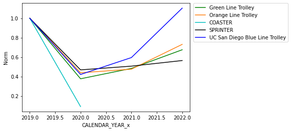

```python
sns.lineplot(x="CALENDAR_YEAR_x", y="Norm", hue="ROUTE_NAME", data=rail_boardings_avg_norm,
            palette={'UC San Diego Blue Line Trolley':'b', 'Green Line Trolley':'g',
                     'Orange Line Trolley':'tab:orange', 'COASTER':'c', 'SPRINTER':'k'})
plt.legend(bbox_to_anchor=(1.02, 1), loc='upper left', borderaxespad=0)
```

We can see the impact of Covid in 2020, then gradual recovery (except for Coaster where we don't have ridership data past 2020 at the moment). Several things stand out to me:

- While all train lines experienced large drops in ridership due to Covid in 2020, the Coaster was hit much harder than the other lines. This is most likely because a higher percentage of riders are commuters, who stopped using the train completely during the peak of the pandemic when many people were tele-working. Unfortunately I do not have 2021-22 data for Coaster, so I can't see how ridership recovered once people started commuting to work again. It would be interesting to compare its recovery to the other lines.
- The trolley lines and Sprinter all had similar ridership drops from 2019-20. While many riders likely stopped using the train to commute, these lines are also used for non-commute trips, so a higher level of ridership was maintained than for the Coaster. There are also demographic differences between riders on each line that likely lead to differing percentages of riders that were essential workers and thus needed to continue using the train to get to work. However, this data does not include demographic information, so I cannot make any definitive conclusions there.
- It is interesting that Sprinter has slightly less of a drop off than the trolley lines in 2020, but then its recovery lags compared to the trolley lines in 2021 and 2022. It would be worth looking into this further. I wonder how service cuts/recovery compared between the trolley lines and Sprinter during this time.
- The Blue line made a much stronger recovery than the other lines, with 2022 ridership exceeding that of 2019 (pre-Covid) while other lines are at less than 80% of pre-Covid ridership. This is likely due primarily to the Mid-Coast extension to UCSD that opened in late 2021, which expanded access to the line and to new destinations. We can see that the Blue line recovered much faster than the other lines in 2022, as expected if the extension made the largest impact. If I had monthly ridership data instead of yearly, I could check to see how performance compared to the other lines before the extension opened in November 2021 to further cement this conclusion.